# AlgoTrading

Amy

2017-08-25

### Amy’s first algorithic trading program. More complicated algo is coming soon…

#### Testing on Amy’s toy stocks FB, AMZN and AMD

**1. Static and Dynamic views of stock prices for the 3 years**

```
Running BatchGetSymbols for:
   tickers = FB, AMZN, AMD
Downloading Data for FB from yahoo (1|3) - Good job!
Downloading Data for AMZN from yahoo (2|3) - Good stuff!
Downloading Data for AMD from yahoo (3|3) - Nice!
```

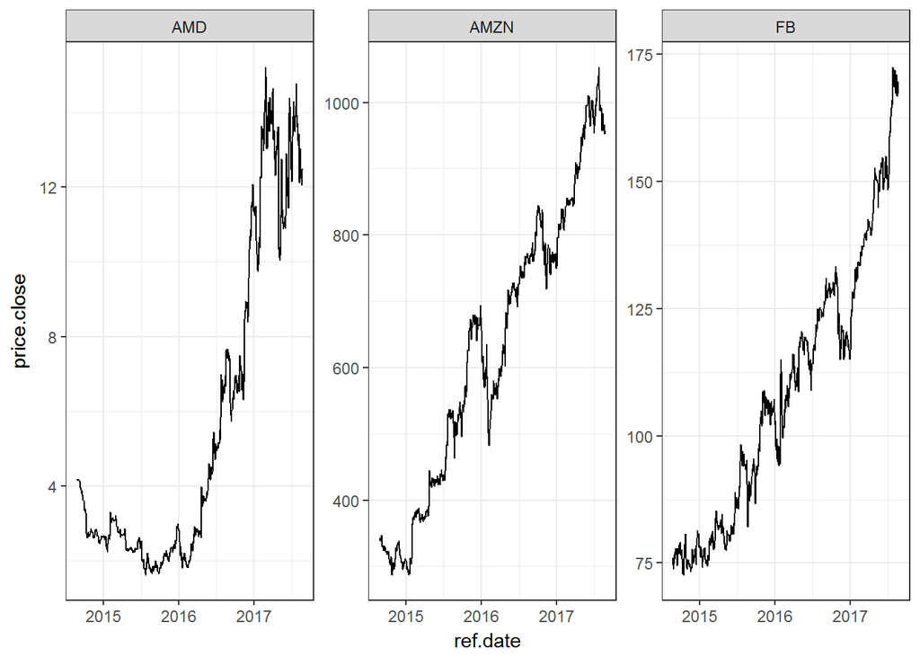

[interactive chart not shown]

**2. A Simple Trading Strategy: Trend Following**

Basic ideas: Basically, you would want to calculate the 200 day and 50 day moving averages for a stock price.On any given day that the 50 day moving average is above the 200 day moving average, you would buy or hold your position. On days where the 200 day average is more than the 50 day moving average, you would sell your shares.

[interactive chart not shown]

### Conclusion

You would want to run the code every day and add a programmatic way to identify stocks that fit the rule based method, **“buy if the 50 day moving average is above the 200 day moving average”**. As you review the preceding chart, the green section is a time in which you would buy the FB equity. The red section represents the time to sell your shares and not reenter.